# Part II - Report on bike-sharing system in SF Bay area for February, 2019

## by Abdulafiz Musa

## Investigation Overview

> My main focus for investigation this data set where the categories of users of this bike-sharing system; gender, user types, birth year and their duration of rides.

## Dataset Overview

> This data set includes information about a bike-sharing system in greater San Francisco Bay area. It includes daily individual rides that occurred in the month of February, 2019. There are 183412 enteries for this individual bike rides during this period.

> Some of the data were converted to log scale in order to observe all points of data. Some null values had to be dropped before observing as some graphs do not function with them around, otherwise all enteries were properly represented.

## Distribution of rides according to duration spent (secs)

> Rides usually last fewer than ten thousands sec. suggesting it isn't for really long distances. Plotting a log scale of the data depicts the entire data properly.

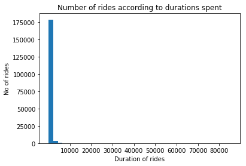

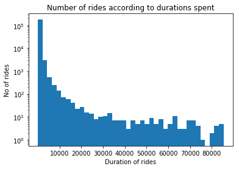

## Distribution of users according to age

> The users are prominently working class (around 1990). We've got a number of old people too as seen in the log scale.

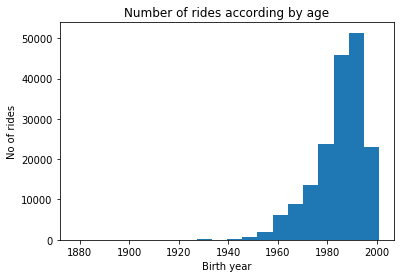

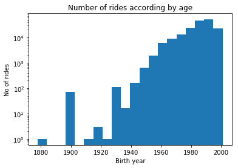

## Relationship between ride duration and birth years

> Interestingly, there was no correlation between the distance traveled and the age of the users of the bike system. Even after considering log scaling.

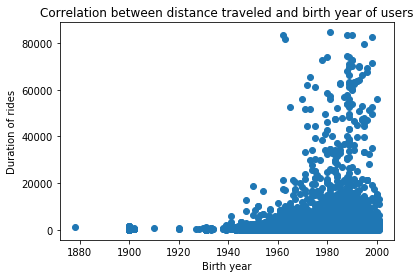

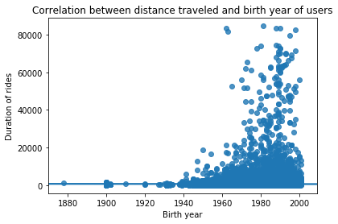

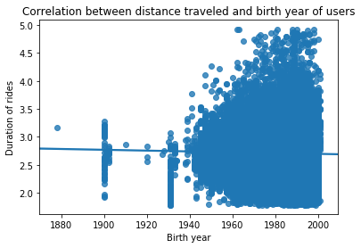

## Relationship between user types and bike sharing

> It has been show that majority of the users are subscribers; it's fun to have observed that either the customers didnt share their bikes on journeys or they just cant and only subscribers are able to do so.

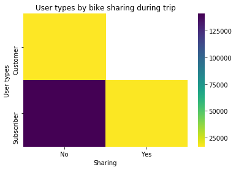

## Predicting duration between take offs and destinations

> Depending on our ability to discern the take off and destination IDs, we can tell how long it wil take us to travel from one area to another; this could be dependent on how busy some areas are too.

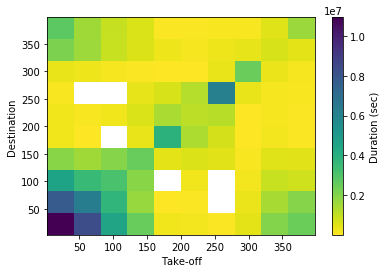

### Conclusion

> It's clearer that customers did not have the capacity to share their bikes. Depending on our ability to discern the take off and destination IDs, we can tell how long it wil take us to travel from one area to another; this could be dependent on how busy some areas are too.